# Knowledge Discovery and Data Visualisation Tutorial 11 (Project II)

By just using the k-NN model without the cross-validation, the best k was found to be 11, and the model itself achieved an accuracy of 0.7342342 on the test set.

The best k from the cross-validation was found to be 3, and the model achieved an accuracy of 0.7432432 on the test set.

This demonstrates that hyperparameter tuning through cross-validation slightly improved the model’s performance, though the improvement was marginal. The increase in accuracy suggests that using a smaller number of neighbors (k=3) allowed the model to better capture local patterns in the data.

2.Model 2: Decision Tree

1. Training

```r
# Load necessary libraries
library(rpart)       # For decision tree
```

```r
library(rpart.plot)  # For tree visualization
decision_tree <- rpart(
  Absence.Category ~ Reason.for.absence + Month.of.absence + Day.of.the.week +
    Transportation.expense + Distance.from.Residence.to.Work +
    Service.time + Age + Work.load.Average.day + Body.mass.index,
  data = train_data,
  method = "class"
)

cat("Summary of Decision Tree:\n")
```

```
## Summary of Decision Tree:
```

```r
print(summary(decision_tree))
```

```
## Call:
## rpart(formula = Absence.Category ~ Reason.for.absence + Month.of.absence +
##     Day.of.the.week + Transportation.expense + Distance.from.Residence.to.Work +
##     Service.time + Age + Work.load.Average.day + Body.mass.index,
##     data = train_data, method = "class")
##   n= 518
##
##           CP nsplit rel error    xerror       xstd
## 1 0.33613445      0 1.0000000 1.0000000 0.04765689
## 2 0.12184874      1 0.6638655 0.6638655 0.04402891
## 3 0.03151261      2 0.5420168 0.5420168 0.04135498
## 4 0.01400560      4 0.4789916 0.4957983 0.04010783
## 5 0.01260504      7 0.4369748 0.5126050 0.04057754
## 6 0.01000000      9 0.4117647 0.5336134 0.04113850
##
## Variable importance
##              Reason.for.absence          Transportation.expense
##                              51                              12
##                             Age                 Body.mass.index
##                               7                               7
##                    Service.time                Month.of.absence
##                               6                               6
## Distance.from.Residence.to.Work           Work.load.Average.day
##                               6                               4
##                 Day.of.the.week
##                               1
##
## Node number 1: 518 observations,    complexity param=0.3361345
##   predicted class=Low   expected loss=0.4594595  P(node) =1
##     class counts:   238   280
##    probabilities: 0.459 0.541
##   left son=2 (236 obs) right son=3 (282 obs)
##   Primary splits:
##       Reason.for.absence     < 22.5     to the left,  improve=38.246690, (0 missing)
##       Transportation.expense < 232      to the right, improve=15.294640, (0 missing)
##       Month.of.absence       < 2.5      to the right, improve= 7.825715, (0 missing)
##       Body.mass.index        < 30.5     to the left,  improve= 7.124375, (0 missing)
##       Service.time           < 10.5     to the right, improve= 6.039862, (0 missing)
##   Surrogate splits:
##       Work.load.Average.day           < 264.4265 to the right, agree=0.587, adj=0.093, (0 split)
```

[output cut: 198 more lines]

```
##     3) Reason.for.absence>=22.5 282  80 Low (0.28368794 0.71631206)
##       6) Transportation.expense>=254 69  32 High (0.53623188 0.46376812)
##        12) Age< 37.5 45  15 High (0.66666667 0.33333333) *
##        13) Age>=37.5 24   7 Low (0.29166667 0.70833333) *
##       7) Transportation.expense< 254 213  43 Low (0.20187793 0.79812207)
##        14) Month.of.absence>=3.5 135  37 Low (0.27407407 0.72592593)
##          28) Reason.for.absence>=24 74  28 Low (0.37837838 0.62162162)
##            56) Reason.for.absence< 26.5 22   6 High (0.72727273 0.27272727) *
##            57) Reason.for.absence>=26.5 52  12 Low (0.23076923 0.76923077)
##             114) Month.of.absence< 8.5 34  12 Low (0.35294118 0.64705882)
##               228) Body.mass.index>=26.5 14   4 High (0.71428571 0.28571429) *
##               229) Body.mass.index< 26.5 20   2 Low (0.10000000 0.90000000) *
##             115) Month.of.absence>=8.5 18   0 Low (0.00000000 1.00000000) *
##          29) Reason.for.absence< 24 61   9 Low (0.14754098 0.85245902) *
##        15) Month.of.absence< 3.5 78   6 Low (0.07692308 0.92307692) *
```

```r
cat("\nVisualizing the Decision Tree:\n")
```

```
##
## Visualizing the Decision Tree:
```

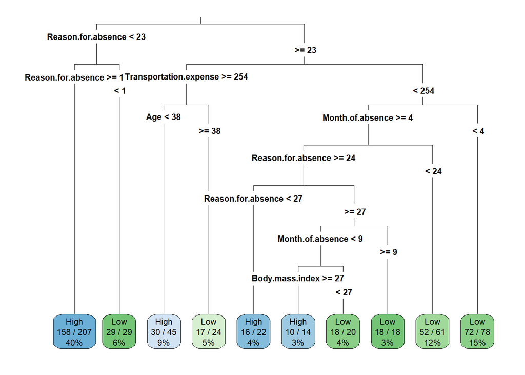

```r
rpart.plot(decision_tree, type = 3, extra = 102, fallen.leaves = TRUE, cex = 0.7)
```

2. Evaluating

```r
tree_predictions <- predict(decision_tree, test_data, type = "class")

tree_accuracy <- mean(tree_predictions == test_data$Absence.Category)
cat("\nDecision Tree Accuracy:", tree_accuracy, "\n")
```

```
##
## Decision Tree Accuracy: 0.8018018
```

```r
cat("\nConfusion Matrix:\n")
```

```
##
## Confusion Matrix:
```

```r
confusion_matrix_tree <- table(Predicted = tree_predictions, Actual = test_data$Absence.Category)
print(confusion_matrix_tree)
```

```
##          Actual
## Predicted High Low
##      High   88  31
##      Low    13  90
```

We chose a decision tree because it is interpretable and can uncover hierarchical relationships between variables. The model was trained to predict absenteeism categories (“High” vs. “Low”), and its structure was visualized to identify the most influential features.

The model achieved an accuracy of 0.8018018 on the test set, meaning it correctly classified absenteeism levels for most cases. However, the unpruned tree may have overfit the training data, as indicated by its complexity. Simplifying the tree through pruning might address this.

3. Pruning

```r
cat("\nComplexity Parameter Table:\n")
```

```
##
## Complexity Parameter Table:
```

```r
printcp(decision_tree)
```

```
##
## Classification tree:
## rpart(formula = Absence.Category ~ Reason.for.absence + Month.of.absence +
##     Day.of.the.week + Transportation.expense + Distance.from.Residence.to.Work +
##     Service.time + Age + Work.load.Average.day + Body.mass.index,
##     data = train_data, method = "class")
##
## Variables actually used in tree construction:
## [1] Age                    Body.mass.index        Month.of.absence
## [4] Reason.for.absence     Transportation.expense
##
## Root node error: 238/518 = 0.45946
##
## n= 518
##
##         CP nsplit rel error  xerror     xstd
## 1 0.336134      0   1.00000 1.00000 0.047657
## 2 0.121849      1   0.66387 0.66387 0.044029
## 3 0.031513      2   0.54202 0.54202 0.041355
## 4 0.014006      4   0.47899 0.49580 0.040108
## 5 0.012605      7   0.43697 0.51261 0.040578
## 6 0.010000      9   0.41176 0.53361 0.041138
```

```r
pruned_tree <- prune(decision_tree, cp = 0.01)  # Adjust 'cp' based on the table
cat("\nVisualizing the Pruned Decision Tree:\n")
```

```
##
## Visualizing the Pruned Decision Tree:
```

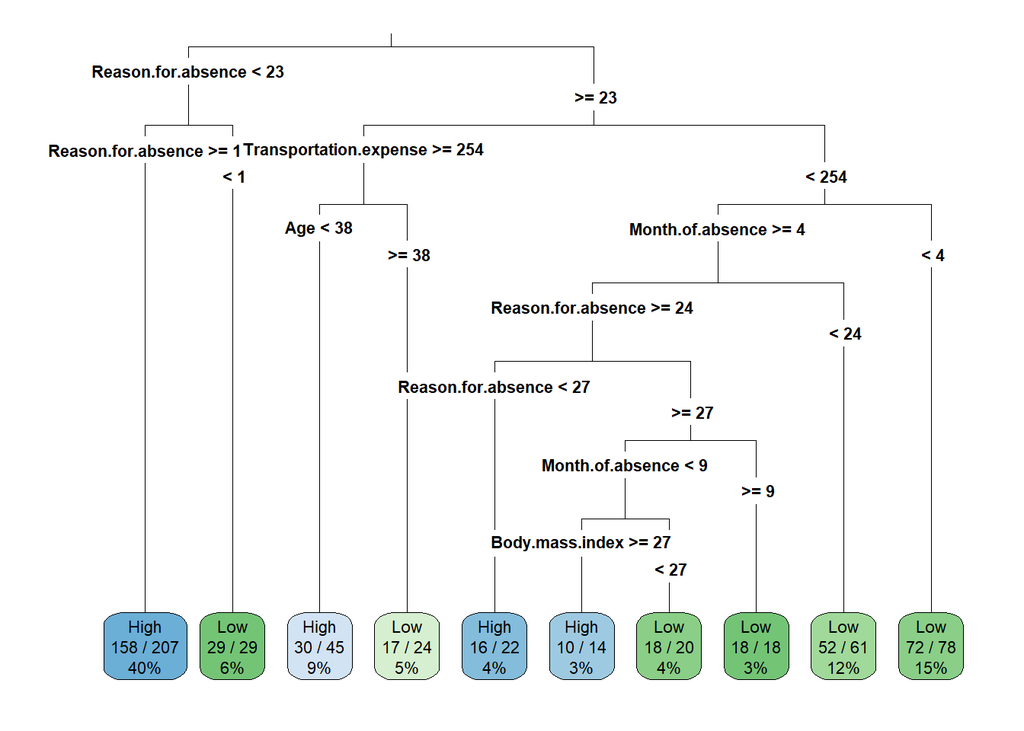

```r
rpart.plot(pruned_tree, type = 3, extra = 102, fallen.leaves = TRUE, cex = 0.7)
```

```r
pruned_predictions <- predict(pruned_tree, test_data, type = "class")
pruned_accuracy <- mean(pruned_predictions == test_data$Absence.Category)
cat("\nPruned Decision Tree Accuracy:", pruned_accuracy, "\n")
```

```
##
## Pruned Decision Tree Accuracy: 0.8018018
```

```r
cat("\nConfusion Matrix for Pruned Tree:\n")
```

```
##
## Confusion Matrix for Pruned Tree:
```

```r
confusion_matrix_pruned <- table(Predicted = pruned_predictions, Actual = test_data$Absence.Category)
print(confusion_matrix_pruned)
```

```
##          Actual
## Predicted High Low
##      High   88  31
##      Low    13  90
```